# project_2_c

## Most interesting graphs and observations

- A handful of outliers were removed for better visualization

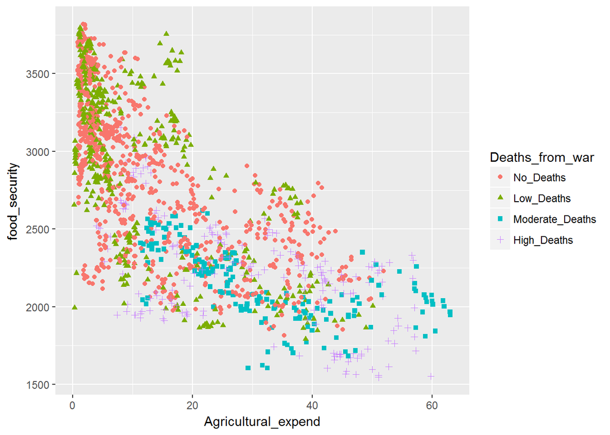

```r
food_war %>%
    ggplot(.,aes(x=Agricultural_expend,y=food_security,shape=Deaths_from_war,color=Deaths_from_war))+
    geom_point()
```

### Graph 1 Agricultural Exp vs Food Security

- Two Clear Clusters develop in the first graph
  - Areas with high death rates seem to be the least food secure and simultaneously spend the most on agricultural subsidy
  - Areas with low death rates spends the least on food subsidy, and are the most food secure

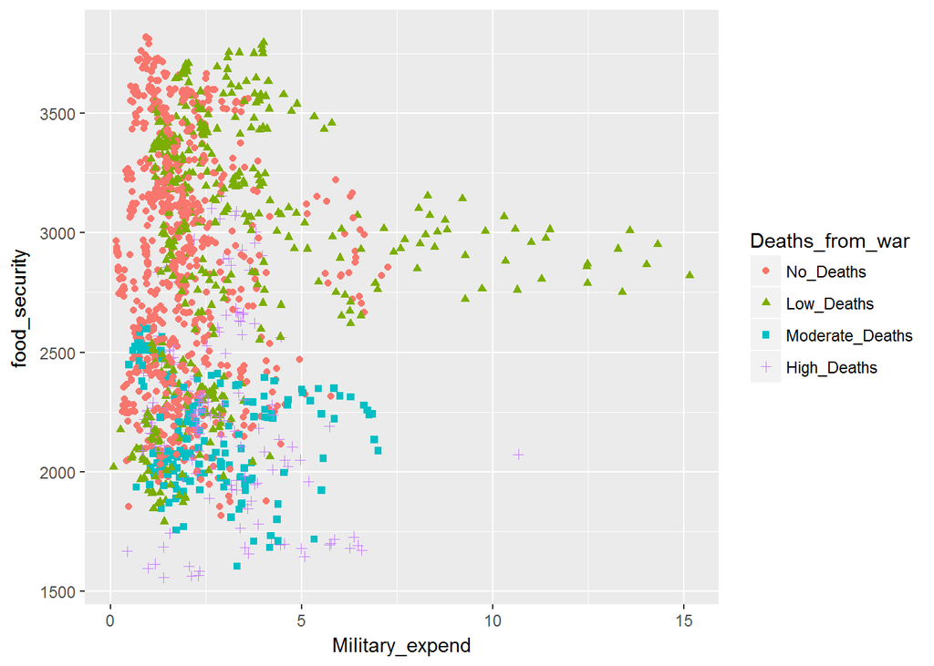

```r
food_war %>%
    filter(.,Military_expend <20) %>%
    ggplot(.,aes(x=Military_expend,y=food_security,shape=Deaths_from_war,color=Deaths_from_war))+
    geom_point()
```

### Graph 2 Military Exp vs Food Security

- Areas with low death rates seem to spend the most on the Military